# **Masculinity Survey**

My Codecademy Masculinity Survey Project from the Data Scientist Path Foundations of Machine Learning: Unsupervised Learning.

### + Project Goal

Find patterns in the way men view masculinity by utilizing the KMeans algorithm on a FiveThirtyEight masculinity survey data.

### + Overview

In this project, I investigated the way people think about masculinity by applying the KMeans algorithm to data from [FiveThirtyEight](https://fivethirtyeight.com/).  
FiveThirtyEight is a popular website known for their use of statistical analysis in many of their stories.

FiveThirtyEight and WNYC studios used `'masculinity-survey.pdf'` to get their male readers' thoughts on masculinity.  
FiveThirtyEight's article [What Do Men Think It Means To Be A Man?](https://fivethirtyeight.com/features/what-do-men-think-it-means-to-be-a-man/) contains their major takeaways.

### + Project Requirements

Be familiar with:

- Python3
- Machine Learning: Unsupervised Learning
- The Python Libraries:
  - Pandas
  - NumPy
  - Matplotlib
  - Sklearn

### + Links

[Blog Masculinity Survey](https://www.alex-ricciardi.com/post/masculinity-survey)  
[Project GitHub](https://github.com/ARiccGitHub/masculinity_project)

## **▪ Libraries**

```python
# Data manipulation tool
import pandas as pd
# Disable pandas copy warnings https://pandas.pydata.org/pandas-docs/stable/user_guide/indexing.html#returning-a-view-versus-a-copy
import warnings
from pandas.core.common import SettingWithCopyWarning
warnings.simplefilter(action="ignore", category=SettingWithCopyWarning)
# Scientific computing, array
import numpy as np
# Data visualization
from matplotlib import pyplot as plt
# Theme to use with matplotlib
from jupyterthemes import jtplot
jtplot.style(theme='chesterish')
# Text I/O (https://docs.python.org/3/library/io.html)
# Utilize in converting the pandas.DataFrame.info() (NoneType) data output into a pandas.DataFrame type data.
try:
    from StringIO import StringIO ## for Python 2
except ImportError:
    from io import StringIO ## for Python 3
# Regex
import re
# K-Means Clustering model
from sklearn.cluster import KMeans
# Convert pandas Dataframe to HTML
from IPython.display import HTML
#---- My Local python files
import column_types as ct
import feature_combinations as fc
```

## **▪ Investigating the Data**

The provided data, `'masculinity.csv'`, contains the FiveThirtyEight survey responses' results from the FiveThirtyEight masculinity survey questions, `'masculinity-survey.pdf'`.

## + The questions

After investigating `'masculinity-survey.pdf'`, I categorized the questions in it as followed:

- Open-end questions

  > [Open-ended questions](https://www.questionpro.com/blog/what-are-open-ended-questions/) are free-form survey questions that allow respondents to answer in open text format so that they can answer based on their complete knowledge, feeling, and understanding. It means that the response to this question is not limited to a set of options.

  The questions 3, 6, 16, 23 and 27 are open-ended questions.  
  Note: the investigating results of the `masculinity.csv` data showed that the data representing the questions above was not provided.
- Masculinity multiple choice questions

  > [Multiple Choice Questions](https://www.questionpro.com/blog/?s=choice+question&lang=en) form the foundation of any survey or questionnaire as they provide a set of answer options for the respondents to select from. They are the perfect means to understand respondent preferences and produce impactful results. Not only do they bring balance to a survey but they also make it easier and quicker for the respondents to answer the survey.

  The following questions, are multiple choice questions:
  - 1 to 2 and 4 to 5 (Ideas about masculinity)
  - 8 to 9 (Lifestyle)
  - 10 through 15 (Employment)<
  - 17 through 22 (Relationships)
  - 24 through 30, and 34 through 36 (Demographics)  
    Note: the questions 34 through 36 are not part of the survey pdf file, but the questions data is found in the data csv file. The questions 31 through 33 are missing from both files.
- Multiple choice questions matrix

  `'Question 7'` is a matrix of multiple choice sub-questions, the matrix is particularly interesting for this project.  
  The sub-questions 7 and 1 through 4 are traditionally seen as feminine activities and the sub-questions 5, 6, 8 and 9 are traditionally seen as masculine activities. The matrix sub-questions' responses can be utilized by the K-Means algorithm to find out if 2 clusters based on those responses represent traditionally feminine and traditionally masculine people.

#### - Questions list

From the information found in `'masculinity-survey.pdf'`, I created a survey question Series using the questions found in the previous cell.  
The python file `'survey_questions.py'` creates the Series.

```python
survey_questions = pd.read_csv('data/survey_questions.csv', index_col = 0, squeeze = True)
survey_questions.to_frame()
```

|  | Survey Questions |
| --- | --- |
| q0001 | In general, how masculine or “manly” do you feel? |
| q0002 | How important is it to you that others see you... |
| q0004 | Where have you gotten your ideas about what it... |
| q0005 | Do you think that society puts pressure on men... |
| q0007_0001 | Ask a friend for professional advice |
| q0007_0002 | Ask a friend for personal advice |
| q0007_0003 | Express physical affection to male friends, li... |
| q0007_0004 | Cry |
| q0007_0005 | Get in a physical fight with another person |
| q0007_0006 | Have sexual relations with women, including an... |
| q0007_0007 | Have sexual relations with men, including anyt... |
| q0007_0008 | Watch sports of any kind |
| q0007_0009 | Work out |
| q0007_0010 | See a therapist |
| q0007_0011 | Feel lonely or isolated |
| q0008 | Which of the following do you worry about on a... |
| q0009 | Which of the following categories best describ... |
| q0010 | In which of the following ways would you say i... |
| q0011 | In which of the following ways would you say i... |
| q0012 | Have you seen or heard of a sexual harassment ... |
| q0013 | And which of the following is the main reason ... |
| q0014 | How much have you heard about the #MeToo movem... |
| q0015 | As a man, would you say you think about your b... |
| q0017 | Do you typically feel as though you’re expecte... |
| q0018 | How often do you try to be the one who pays wh... |
| q0019 | Which of the following are reasons why you try... |
| q0020 | When you want to be physically intimate with s... |
| q0021 | Over the past 12 months, when it comes to sexu... |
| q0022 | Have you changed your behavior in romantic rel... |
| q0024 | Are you now married, widowed, divorced, separa... |
| q0025 | Do you have any children? |
| q0026 | Would you describe your sexual orientation as: |
| q0028 | Are you: |
| q0029 | What is the last grade of school you completed? |
| q0030 | What state do you live in? |
| q0034 | Income |
| q0035 | Time Zone |
| q0036 | Device |

## + The response data

The response data is found in the provided `'masculinity.csv'` file.

I loaded the data into a DataFrame named `'survey'`. This file contains the raw response data from the masculinity survey.

I answered the following questions using the Pandas library functionality:

- What are the names of the columns?
- How many rows are there?
- How many people said they often ask a friend for professional advice? This is the first sub-question in the matrix question 7.
- And more.

```python
# Loading data
survey = pd.read_csv("masculinity.csv").drop(columns=['Unnamed: 0'])
survey
```

|  | StartDate | EndDate | q0001 | q0002 | q0004_0001 | q0004_0002 | q0004_0003 | q0004_0004 | q0004_0005 | q0004_0006 | ... | q0035 | q0036 | race2 | racethn4 | educ3 | educ4 | age3 | kids | orientation | weight |
| --- | --- | --- | --- | --- | --- | --- | --- | --- | --- | --- | --- | --- | --- | --- | --- | --- | --- | --- | --- | --- | --- |
| 0 | 5/10/18 4:01 | 5/10/18 4:06 | Somewhat masculine | Somewhat important | Not selected | Not selected | Not selected | Pop culture | Not selected | Not selected | ... | Middle Atlantic | Windows Desktop / Laptop | Non-white | Hispanic | College or more | College or more | 35 - 64 | No children | Gay/Bisexual | 1.714026 |
| 1 | 5/10/18 6:30 | 5/10/18 6:53 | Somewhat masculine | Somewhat important | Father or father figure(s) | Not selected | Not selected | Not selected | Not selected | Not selected | ... | East North Central | iOS Phone / Tablet | White | White | Some college | Some college | 65 and up | Has children | Straight | 1.247120 |
| 2 | 5/10/18 7:02 | 5/10/18 7:09 | Very masculine | Not too important | Father or father figure(s) | Not selected | Not selected | Not selected | Not selected | Other (please specify) | ... | East North Central | Windows Desktop / Laptop | White | White | College or more | College or more | 35 - 64 | Has children | Straight | 0.515746 |
| 3 | 5/10/18 7:27 | 5/10/18 7:31 | Very masculine | Not too important | Father or father figure(s) | Mother or mother figure(s) | Other family members | Not selected | Not selected | Not selected | ... | East North Central | Windows Desktop / Laptop | White | White | Some college | Some college | 65 and up | Has children | No answer | 0.600640 |
| 4 | 5/10/18 7:35 | 5/10/18 7:42 | Very masculine | Very important | Not selected | Not selected | Other family members | Not selected | Not selected | Not selected | ... | East North Central | Windows Desktop / Laptop | White | White | College or more | College or more | 35 - 64 | No children | Straight | 1.033400 |
| ... | ... | ... | ... | ... | ... | ... | ... | ... | ... | ... | ... | ... | ... | ... | ... | ... | ... | ... | ... | ... | ... |
| 1184 | 5/19/18 7:50 | 5/19/18 8:00 | Somewhat masculine | Not at all important | Not selected | Mother or mother figure(s) | Not selected | Not selected | Not selected | Not selected | ... | East North Central | Windows Desktop / Laptop | Non-white | Other | Some college | Some college | 35 - 64 | No children | Gay/Bisexual | 1.571755 |
| 1185 | 5/19/18 7:52 | 5/19/18 8:03 | Somewhat masculine | Somewhat important | Not selected | Not selected | Not selected | Not selected | Not selected | Other (please specify) | ... | New England | Windows Desktop / Laptop | White | White | High school or less | High school or less | 35 - 64 | Has children | Straight | 2.446719 |
| 1186 | 5/19/18 7:58 | 5/19/18 8:04 | Very masculine | Very important | Father or father figure(s) | Mother or mother figure(s) | Not selected | Not selected | Not selected | Not selected | ... | Pacific | iOS Phone / Tablet | White | White | Some college | Some college | 65 and up | Has children | Straight | 0.615180 |
| 1187 | 5/19/18 8:52 | 5/19/18 8:59 | Somewhat masculine | Very important | Father or father figure(s) | Mother or mother figure(s) | Not selected | Pop culture | Not selected | Not selected | ... | Middle Atlantic | iOS Phone / Tablet | Non-white | Other | College or more | College or more | 18 - 34 | No children | Straight | 2.965508 |
| 1188 | 5/19/18 8:56 | 5/19/18 9:02 | Somewhat masculine | Somewhat important | Father or father figure(s) | Mother or mother figure(s) | Not selected | Not selected | Not selected | Not selected | ... | Pacific | Android Phone / Tablet | White | W | NaN | NaN | NaN | NaN | NaN | NaN |

1189 rows × 97 columns

#### - Columns

```python
# Survey Info
output = StringIO()
# Write info to a string buffer
survey.info(buf=output, verbose=True, null_counts=True)
# Stores the info into a pandas.Series
survey_info =  pd.Series(data=output.getvalue().split('\n'))
# Saves survey info
survey_info.to_csv('data/survey_info.csv')
survey_info.head(20)
```

```
0         <class 'pandas.core.frame.DataFrame'>
1           RangeIndex: 1189 entries, 0 to 1188
2              Data columns (total 97 columns):
3      #   Column       Non-Null Count  Dtype
4     ---  ------       --------------  -----
5      0   StartDate    1189 non-null   object
6      1   EndDate      1189 non-null   object
7      2   q0001        1189 non-null   object
8      3   q0002        1189 non-null   object
9      4   q0004_0001   1189 non-null   object
10     5   q0004_0002   1189 non-null   object
11     6   q0004_0003   1189 non-null   object
12     7   q0004_0004   1189 non-null   object
13     8   q0004_0005   1189 non-null   object
14     9   q0004_0006   1189 non-null   object
15     10  q0005        1189 non-null   object
16     11  q0007_0001   1189 non-null   object
17     12  q0007_0002   1189 non-null   object
18     13  q0007_0003   1189 non-null   object
19     14  q0007_0004   1189 non-null   object
dtype: object
```

The `'Dtypes'` is showing mostly object data types, using `'column_types()'` function will show what kind of data type the objects are.

```python
survey_column_types = ct.column_types(survey)
survey_column_types.to_csv('data/survey_column_types.csv')
pd.set_option('display.max_rows', 200)
survey_column_types.style.set_properties(subset=['pandas_dtype', 'python_type'],**{'text-align': 'center'})
```

|  | Columns | pandas_dtype | python_type |
| --- | --- | --- | --- |
| 0 | StartDate | object | str |
| 1 | EndDate | object | str |
| 2 | q0001 | object | str |
| 3 | q0002 | object | str |
| 4 | q0004_0001 | object | str |
| 5 | q0004_0002 | object | str |
| 6 | q0004_0003 | object | str |
| 7 | q0004_0004 | object | str |
| 8 | q0004_0005 | object | str |
| 9 | q0004_0006 | object | str |
| 10 | q0005 | object | str |
| 11 | q0007_0001 | object | str |
| 12 | q0007_0002 | object | str |
| 13 | q0007_0003 | object | str |
| 14 | q0007_0004 | object | str |
| 15 | q0007_0005 | object | str |
| 16 | q0007_0006 | object | str |
| 17 | q0007_0007 | object | str |
| 18 | q0007_0008 | object | str |
| 19 | q0007_0009 | object | str |
| 20 | q0007_0010 | object | str |
| 21 | q0007_0011 | object | str |
| 22 | q0008_0001 | object | str |
| 23 | q0008_0002 | object | str |
| 24 | q0008_0003 | object | str |
| 25 | q0008_0004 | object | str |
| 26 | q0008_0005 | object | str |
| 27 | q0008_0006 | object | str |
| 28 | q0008_0007 | object | str |
| 29 | q0008_0008 | object | str |

[output cut: 67 more lines]

#### - Checking for duplicated columns

- `'race2'` and `'racethn4'`
- `'educ3'` and `'educ4'`

```python
# race2 and racethn4
display(survey['race2'].value_counts())
survey['racethn4'].value_counts()
```

```
White        1015
Non-white     174
Name: race2, dtype: int64
```

```
White       1014
Other         92
Hispanic      41
Black         41
W              1
Name: racethn4, dtype: int64
```

The columns `'race2'` and `'racethn4'` are not duplicated columns.  
The column `'race2'` classifies survey responders as `'White'` or `'Non_white'`.  
The column `'racethn4'` classifies survey responders as `'Black'`, `'White'`, `'Hispanic'`, `'Other'` and 1 `'W'`.

```python
# educ3 and educ4
for i in range(10):
    if survey['educ3'][i] != survey['educ4'][i]:
        print(survey['educ3'][i])
        print(survey['educ4'][i])
```

```
College or more
Post graduate degree
College or more
Post graduate degree
College or more
Post graduate degree
```

Some of the values `'College or more'` from the column `'educ3'` have been replaced by the value `'Post graduate degree'` in the column `'educ4'`. Even if the columns `'educ3'` and `'educ4'` are not exact duplicates of each other, I decided to drop the column `'educ3'` from the `'survey'` DataFrame, and rename the the column `'educ4'`, `'education'`.

```python
survey = survey.drop(['educ3'], axis=1).rename(columns={'educ4':'education'})
survey.columns
```

```
Index(['StartDate', 'EndDate', 'q0001', 'q0002', 'q0004_0001', 'q0004_0002',
       'q0004_0003', 'q0004_0004', 'q0004_0005', 'q0004_0006', 'q0005',
       'q0007_0001', 'q0007_0002', 'q0007_0003', 'q0007_0004', 'q0007_0005',
       'q0007_0006', 'q0007_0007', 'q0007_0008', 'q0007_0009', 'q0007_0010',
       'q0007_0011', 'q0008_0001', 'q0008_0002', 'q0008_0003', 'q0008_0004',
       'q0008_0005', 'q0008_0006', 'q0008_0007', 'q0008_0008', 'q0008_0009',
       'q0008_0010', 'q0008_0011', 'q0008_0012', 'q0009', 'q0010_0001',
       'q0010_0002', 'q0010_0003', 'q0010_0004', 'q0010_0005', 'q0010_0006',
       'q0010_0007', 'q0010_0008', 'q0011_0001', 'q0011_0002', 'q0011_0003',
       'q0011_0004', 'q0011_0005', 'q0012_0001', 'q0012_0002', 'q0012_0003',
       'q0012_0004', 'q0012_0005', 'q0012_0006', 'q0012_0007', 'q0013',
       'q0014', 'q0015', 'q0017', 'q0018', 'q0019_0001', 'q0019_0002',
       'q0019_0003', 'q0019_0004', 'q0019_0005', 'q0019_0006', 'q0019_0007',
       'q0020_0001', 'q0020_0002', 'q0020_0003', 'q0020_0004', 'q0020_0005',
       'q0020_0006', 'q0021_0001', 'q0021_0002', 'q0021_0003', 'q0021_0004',
       'q0022', 'q0024', 'q0025_0001', 'q0025_0002', 'q0025_0003', 'q0026',
       'q0028', 'q0029', 'q0030', 'q0034', 'q0035', 'q0036', 'race2',
       'racethn4', 'education', 'age3', 'kids', 'orientation', 'weight'],
      dtype='object')
```

#### - Number of people who said that they often ask a friend for professional advice:

First sub-question of the `question 7`.

```python
q0007_0001_count = survey["q0007_0001"].value_counts().to_frame()
display(q0007_0001_count.style.set_properties(**{'text-align': 'center'}))
q0007_0001_count.loc['Often'].to_frame().style.set_properties(**{'text-align': 'center'})
```

|  | q0007_0001 |
| --- | --- |
| Sometimes | 537 |
| Rarely | 324 |
| Often | 142 |
| Never, but open to it | 123 |
| Never, and not open to it | 53 |
| No answer | 10 |

|  | Often |
| --- | --- |
| q0007_0001 | 142 |

#### - The questions 34 through 36 are not described in the `masculinity-survey.pdf`.

I investigated the response data to find out the questions' topics.

```python
for question in ['q0034', 'q0035', 'q0036']:
    print(f'\nQuestion: {question}')
    display(survey[question].value_counts())
```

```
Question: q0034
```

```
$50,000-$74,999         197
$75,000-$99,999         174
$25,000-$49,999         163
Prefer not to answer    162
$100,000-$124,999       131
$200,000+                95
$10,000-$24,999          71
$125,000-$149,999        66
$0-$9,999                49
$150,000-$174,999        49
$175,000-$199,999        30
Name: q0034, dtype: int64
```

```
Question: q0035
```

```
Pacific               224
South Atlantic        218
Middle Atlantic       172
East North Central    151
West South Central    113
Mountain              111
West North Central     83
New England            62
East South Central     43
Name: q0035, dtype: int64
```

```
Question: q0036
```

```
Windows Desktop / Laptop    664
iOS Phone / Tablet          223
Android Phone / Tablet      157
MacOS Desktop / Laptop      121
Other                        22
Name: q0036, dtype: int64
```

From the response data I deducted:

- The question-34 topic is about the survey responder income.
- The question-35 topic is about the survey responder time zone.
- The question-36 topic is about device used by the responder to take the survey.

## **▪ Mapping the Data**

In order to use the K-Means algorithm with this data, I needed to first figure out how to turn the response data into numerical data.  
For this exercise, I chose to use the response data from `'question 7'`, the question is a matrix of multiple choice sub-questions.  
The sub-questions 7 and 1 through 4 are traditionally seen as feminine activities and the questions 5, 6, 8 and 9 are traditionally seen as masculine activities.  
The matrix sub-questions' responses can be utilized by the K-Means algorithm to find out if 2 clusters based on those responses represent traditionally feminine and traditionally masculine people.  
I could cluster the data using the phrases `'Often'` or `'Rarely'`, but I needed to turn the phrases into numbers, I decided to map the data in the following way:

- `"Often"` -> `4`
- `"Sometimes"` -> `3`
- `"Rarely"` -> `2`
- `"Never, but open to it"` -> `1`
- `"Never, and not open to it"` -> `0`.

Note, it's important that these responses are somewhat linear. `'Often'` is at one end of the spectrum with `'Never, and not open to it'` at the other. The other values fall in sequence between the two. I could perform a similar mapping for the `'education'` responses , but there isn't an obvious linear progression in the `'racethn4'` responses.

### + The map_responses() function

The function maps a given question sub-question response data to numerical data.

- Takes the arguments:
  - responses_list, a list data type
  - q_list, a list data type
  - question_ref, a string data type
- Finds sub-questions names
- Maps sub-questions responses data to a numeric data
- Returns a mapped responses DataFrame

```python
def map_responses(responses_list, responses_ref):
    # Finds question sub-questions responses reference
    pattern = re.compile(responses_ref)
    q_col_name = [col_name for col_name in survey.columns if pattern.match(col_name)]
    # Maps sub-questions' responses to numeric data
    # Stores results into a DataFrame
    map_responses = pd.DataFrame()
    for col in q_col_name:
         map_responses[col] = survey[col].map({responses_list[i] : i for i in range(len(responses_list))})

    return map_responses
```

### + Mapping question 7 responses

Mapping question 7 sub-questions responses and displaying the responses counts.

```python
# List of responses
q0007_responses_list = ['Never, and not open to it', 'Never, but open to it', 'Rarely', 'Sometimes', 'Often']
# Maps question 7 sub-question responses
q0007_responses = map_responses(q0007_responses_list, 'q0007')
q0007_responses.to_csv('data/q0007_responses.csv')
# Value count question 7 sub-question 1
q0007_0001_responses_count = q0007_responses['q0007_0001'].value_counts().to_frame().sort_index().reset_index().rename(columns={'index':'response_num'})
# map_q0007_0001['sub_questions'] = sub_q0007_list
q0007_0001_responses_count['responses'] = q0007_responses_list
q0007_0001_responses_count = q0007_0001_responses_count[['responses', 'q0007_0001']]
# Adds the mapped questions number reference list
q0007_0001_responses_count.reset_index(inplace=True)
q0007_0001_responses_count = q0007_0001_responses_count.rename(columns={'index':'mapped responses'})
# Sets the output display precision in terms of decimal places, 0.
pd.set_option('precision', 0)
q0007_0001_responses_count.style.hide_index().set_properties(subset=['mapped responses', 'q0007_0001'],**{'text-align': 'center'})
```

| mapped responses | responses | q0007_0001 |
| --- | --- | --- |
| 0 | Never, and not open to it | 53 |
| 1 | Never, but open to it | 123 |
| 2 | Rarely | 324 |
| 3 | Sometimes | 537 |
| 4 | Often | 142 |

## **▪ Plotting Question 7 Response data**

The `'question 7'` has 11 different features, sub-questions, I could plug in the sub-questions response data into a K-Means algorithm, but first I wanted to explore the sub-questions' responses further, I visualized the features into a grid of 2D scatter plots, comparing the features data the each other.

### + Question 7 sub-questions

```python
# List of sub-questions
q0007_list = ['Ask a friend for professional advice',
              'Ask a friend for personal advice',
              'Express physical affection to male friends, like hugging, rubbing shoulders',
              'Cry',
              'Get in a physical fight with another person',
              'Have sexual relations with women, including anything from kissing to sex',
              'Have sexual relations with men, including anything from kissing to sex',
              'Watch sports of any kind',
              'Work out',
              'See a therapist',
              'Feel lonely or isolated']
```

### + The plot_features() function

The function scatter plots a given question sub-question's responses into a grid of 2d graphs.

- Takes the arguments:
  - questions_list, a list data type
  - responses, a DataFrame data type
  - responses_list, a list data type
  - question_name, a string data type
- plots grid of scatters plots
- Saves grid

```python
def plot_features(questions_list, responses, responses_list, question_name):
    # nCr combination to combine the mapped question responses
    comb_responses = list(fc.f_combinations(responses.columns, 2))
    comb_questions_list = list(fc.f_combinations(questions_list, 2))
    # Numbers of 2 responses combinations
    num_comb = len(comb_responses)
    # Plot index counter used when displaying scatter plot matrix
    k=1
    # Rows counter, number of rows needed for a 4 columns plotting grid
    if  num_comb%4 == 0:
        rows = num_comb/4
    else:
        rows = (num_comb+4-(num_comb%4))/4
    # Initializes figure
    grid = plt.figure(figsize=(28, 7*rows))
    plt.subplots_adjust(wspace=0.2, hspace=4/rows)
    # Grid
    for i in range(num_comb):
        # Combination responses
        responses_1 = comb_responses[i][0]
        responses_2 = comb_responses[i][1]
        # Combination sub-question
        sub_q_1 = comb_questions_list[i][0]
        sub_q_2 = comb_questions_list[i][1]
        # Plot grid location
        plt.subplot(int(rows), 4, k)
        # Scatters plot
        plt.scatter(
            responses[responses_1],
            responses[responses_2],
            alpha = 0.05,
            s=100,
            color='y'
        )
        # Ticks
        plt.xticks(np.arange(0, len(responses_list), step=1))
        plt.yticks(np.arange(0,  len(responses_list), step=1))
        # Labels
        plt.xlabel(responses_1)
        plt.ylabel(responses_2)
        # Increment Plot index counter
        k+=1
        # Grid title, question
        if i == 2:
            plt.text(
                -0.5,
                len(responses_list)+1,
                question_name,
                fontsize=34,
                horizontalalignment='center',
                verticalalignment='center',
                bbox=dict(
                    facecolor='#323a47',
                    edgecolor='None'
                )
            )
        # Questions legend
        if i == 0:
            questions = responses.columns
            legend = ''.join( str(e) for e in [f'{questions[i]} : {questions_list[i]}\n' for i in range(len(questions))])
            plt.text(
                0,
                len(responses_list)+0.7,
                legend,
                fontsize=14,
                color='w',
                horizontalalignment='left',
                verticalalignment='center',
                bbox=dict(facecolor='#323a47', edgecolor='None')
            )
        # responses legend
        if i == 3:
            legend = ''.join( str(e) for e in [f'{i} : {responses_list[i]}\n' for i in range(len(responses_list))])
            plt.text(
                0,
                len(responses_list)+0.7,
                legend,
                fontsize=14,
                horizontalalignment='left',
                verticalalignment='center',
                bbox=dict(facecolor='#323a47', edgecolor='None')
            )

    plt.savefig(f'graph/{question_name}.png')
    plt.show()
```

### + Plotting question 7

Plotting `question 7` sub-questions' responses.

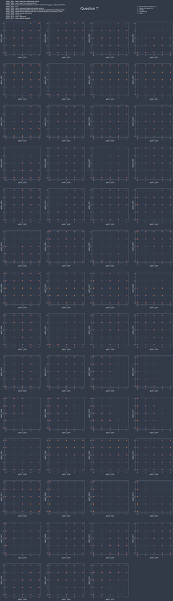

```python
plot_features(q0007_list, q0007_responses, q0007_responses_list, 'Question 7')
```

#### - Analyzing scatter plots

The grid has 55 features combinations, 55 scatter plots.  
In this section I looked at some interesting features combinations including the responses data from the question `'q0007_0001'` , *'Ask a friend for professional advice'*.

- `'q000_0001'` vs `'q000_0002'`  
  *'Ask a friend for professional advice'* vs *'Ask a friend for personal advice'*.  
  The scatter plots show, if the responder is less likely to ask a friend for professional advice, he is also less likely to ask a friend for personal advice.  
  On the other hand, if the responder is more likely to ask a friend for professional advice, he is also more likely to ask a friend for personal advice.
- `'q000_0001'` vs `'q000_0003'`  
  *'Ask a friend for professional advice'* vs *'Express physical affection to male friends, like hugging, rubbing shoulders'*.  
  The scatter plots show, if the responder is less likely to ask a friend for professional advice, he is also less likely to express physical affection to male friends.  
  On the other hand, if the responder is more likely to ask a friend for professional advice, he is also more likely to express physical affection to male friends.
- `'q000_0001'` vs `'q000_0004'`  
  *'Ask a friend for professional advice'* vs *'Cry'*.  
  The scatter plots show, when compared to all other responses, if the responder answer to the question *'Ask a friend for professional advice'* is `'Never, and not open to it'`, the responder is less likely to cry or to admit that he cries.
- `'q000_0001'` vs `'q000_0007'`  
  *'Ask a friend for professional advice'* vs *'Have sexual relations with men, including anything from kissing to sex'*.  
  The scatter plots show, when compared to all other responses, if the responder answer to the question *Ask a friend for professional advice* is `'Sometimes'`, the responder is more likely to be open to have sexual relations with men.
- `'q000_0001'` vs `'q000_0010'`  
  '*Ask a friend for professional advice'* vs *'See a therapist'*.  
  The scatter plots show, if the responder is less likely to ask a friend for professional advice, he is also is less likely to see a therapist.  
  On the other hand, if the responder is more likely to ask a friend for professional advice, he is also more likely to to see a therapist.
- `'q000_0001'` vs `'q000_0011'`  
  *'Ask a friend for professional advice'* vs '*'Feel lonely or isolated'*.  
  The scatter plots show, when compared to all other responses, if the responder answer to the question *'Ask a friend for professional advice'* is `'Never, and not open to it'`, the responder is less likely to not feel lonely or isolated or to admit that he feels lonely or isolated.

## **▪ K-Means Model**

> K-Means clustering is one of the simplest and popular unsupervised machine learning algorithms. [Understanding K-means Clustering in Machine Learning](https://towardsdatascience.com/understanding-k-means-clustering-in-machine-learning-6a6e67336aa1)  
> The objective of K-Means is simple: group similar data points together and discover underlying patterns. To achieve this objective, K-means looks for a fixed number (k) of clusters in a dataset. [AndreyBu](https://www.education-ecosystem.com/andreybu/REaxr-machine-learning-model-python-sklearn-kera/oPGdP-machine-learning-model-python-sklearn-kera/)

For this exercise, I used [sklearn.cluster.KMeans](https://scikit-learn.org/stable/modules/generated/sklearn.cluster.KMeans.html) K-Means algorithm from the SKlearn python library, and the responses data from `'question 7'`, like I described earlier, the question is a matrix of multiple choice sub-questions.  
The sub-questions 7 and 1 through 4 are traditionally seen as feminine activities and the sub-questions 5, 6, 8 and 9 are traditionally seen as masculine activities.  
I used the K-Means algorithm to explore the sub-questions' responses and find out if 2 clusters based on those responses represent traditionally feminine and traditionally masculine people.

### + Training model with selected question 7 sub-question responses

#### - Training

```python
# Isolates selected sub-questions and drops NaN values columns
# Finds question 7 sub-questions names
pattern = re.compile('q0007')
q0007_id = [col_name for col_name in survey.columns if pattern.match(col_name)]
q0007_responses = q0007_responses.dropna(subset = q0007_id )
# Initializes K-Means model,
# the argument "random_state = 1 "sets the random seed to 1, to ensure that results are reproducible
classifier = KMeans(n_clusters = 2, random_state=1)
# Training/Classifying selected sub-question responses
classifier.fit(q0007_responses[q0007_id])
```

```
KMeans(n_clusters=2, random_state=1)
```

#### - Centroids

```python
# Stores centroids coordinates
centroids_q0007 = pd.DataFrame(classifier.cluster_centers_)
# Display
pd.set_option('precision', 8)
centroids_q0007.style.hide_index()
```

| 0 | 1 | 2 | 3 | 4 | 5 | 6 | 7 | 8 | 9 | 10 |
| --- | --- | --- | --- | --- | --- | --- | --- | --- | --- | --- |
| 2.85536547 | 2.83514774 | 2.83981337 | 2.43856921 | 0.72006221 | 2.74494557 | 0.52410575 | 2.97356143 | 2.80404355 | 1.53499222 | 2.39191291 |
| 1.90789474 | 1.85000000 | 0.95789474 | 1.66842105 | 0.53421053 | 2.88157895 | 0.08421053 | 2.80263158 | 2.17631579 | 0.61052632 | 1.66842105 |

Note: The inputted data has 11 features and 2 clusters, `'cluster_centers'` returns 2 centroids in 11-dimensions (1 dimension per sub-question). Each list corresponds to the coordinates of the centroids in R^11.

```python
# Renames columns
centroids_q0007 = centroids_q0007.rename(columns={i:f'R^{i+1}' for i in range(len(centroids_q0007.columns))})
# Adds a cluster number column
centroids_q0007['clusters'] = [1, 2]
# Rearranges columns
col_list = ['clusters']+[ centroids_q0007.columns[i] for i in range(len(centroids_q0007.columns)-1)]
centroids_q0007 = centroids_q0007[col_list]
# Saves and display DataFrame
centroids_q0007.to_csv('data/centroids_q0007.csv')
centroids_q0007.style.hide_index().set_properties(subset=['clusters'],**{'text-align': 'center'})
```

| clusters | R^1 | R^2 | R^3 | R^4 | R^5 | R^6 | R^7 | R^8 | R^9 | R^10 | R^11 |
| --- | --- | --- | --- | --- | --- | --- | --- | --- | --- | --- | --- |
| 1 | 2.85536547 | 2.83514774 | 2.83981337 | 2.43856921 | 0.72006221 | 2.74494557 | 0.52410575 | 2.97356143 | 2.80404355 | 1.53499222 | 2.39191291 |
| 2 | 1.90789474 | 1.85000000 | 0.95789474 | 1.66842105 | 0.53421053 | 2.88157895 | 0.08421053 | 2.80263158 | 2.17631579 | 0.61052632 | 1.66842105 |

## **▪ Separating by clusters**

I was able to find out more information about the clusters by looking at the specific members of each cluster. `'classifier.labels_'` shows which cluster every row in the DataFrame corresponds to.

For example, if `'classifier.labels_'` was `[1, 0 ,1]`, then the first row in the DataFrame would be in cluster one, the second row would be in cluster 0, and the third row would be in cluster one. A row represents one persons responses to every question in the survey.

```python
classifier.labels_
```

```
array([0, 0, 1, ..., 0, 1, 1])
```

### + Adding model classifications results to the q0007_responses DataFrame

```python
q0007_responses['clusters'] = classifier.labels_
q0007_responses
```

|  | q0007_0001 | q0007_0002 | q0007_0003 | q0007_0004 | q0007_0005 | q0007_0006 | q0007_0007 | q0007_0008 | q0007_0009 | q0007_0010 | q0007_0011 | clusters |
| --- | --- | --- | --- | --- | --- | --- | --- | --- | --- | --- | --- | --- |
| 0 | 4.0 | 4.0 | 4.0 | 4.0 | 0.0 | 0.0 | 4.0 | 3.0 | 3.0 | 0.0 | 4.0 | 0 |
| 2 | 3.0 | 3.0 | 3.0 | 2.0 | 1.0 | 4.0 | 0.0 | 2.0 | 3.0 | 2.0 | 0.0 | 0 |
| 3 | 2.0 | 2.0 | 3.0 | 2.0 | 2.0 | 4.0 | 0.0 | 0.0 | 2.0 | 0.0 | 0.0 | 1 |
| 4 | 3.0 | 2.0 | 0.0 | 1.0 | 1.0 | 3.0 | 0.0 | 4.0 | 2.0 | 1.0 | 3.0 | 1 |
| 5 | 1.0 | 3.0 | 3.0 | 2.0 | 1.0 | 4.0 | 0.0 | 3.0 | 4.0 | 1.0 | 0.0 | 0 |
| ... | ... | ... | ... | ... | ... | ... | ... | ... | ... | ... | ... | ... |
| 1183 | 4.0 | 4.0 | 3.0 | 3.0 | 0.0 | 2.0 | 0.0 | 0.0 | 2.0 | 1.0 | 3.0 | 0 |
| 1185 | 3.0 | 3.0 | 2.0 | 2.0 | 1.0 | 4.0 | 0.0 | 4.0 | 4.0 | 3.0 | 2.0 | 0 |
| 1186 | 4.0 | 3.0 | 0.0 | 3.0 | 2.0 | 4.0 | 0.0 | 3.0 | 3.0 | 1.0 | 3.0 | 0 |
| 1187 | 1.0 | 1.0 | 0.0 | 0.0 | 3.0 | 3.0 | 0.0 | 4.0 | 4.0 | 0.0 | 2.0 | 1 |
| 1188 | 2.0 | 2.0 | 2.0 | 0.0 | 0.0 | 3.0 | 0.0 | 0.0 | 2.0 | 0.0 | 2.0 | 1 |

1023 rows × 12 columns

### + Separating question 7 response data by clusters

```python
# Cluster 1
q0007_responses_to_cluster_1 = q0007_responses.loc[q0007_responses['clusters'] == 0].drop('clusters', axis=1)
# Cluster 2
q0007_responses_to_cluster_2 = q0007_responses.loc[q0007_responses['clusters'] == 1].drop('clusters', axis=1)
# Samples
print('Question 7 Cluster-1:')
display(q0007_responses_to_cluster_1)
print(f'Values of cluster_1 DataFrame loc[2]:\n\n{q0007_responses_to_cluster_1.loc[2]}')
print(f'\nIndex values of question 7 cluster-1 DataFrame at index 0 to 9:\n{[q0007_responses_to_cluster_1.index[i] for i in range(10)]}')
```

```
Question 7 Cluster-1:
```

|  | q0007_0001 | q0007_0002 | q0007_0003 | q0007_0004 | q0007_0005 | q0007_0006 | q0007_0007 | q0007_0008 | q0007_0009 | q0007_0010 | q0007_0011 |
| --- | --- | --- | --- | --- | --- | --- | --- | --- | --- | --- | --- |
| 0 | 4.0 | 4.0 | 4.0 | 4.0 | 0.0 | 0.0 | 4.0 | 3.0 | 3.0 | 0.0 | 4.0 |
| 2 | 3.0 | 3.0 | 3.0 | 2.0 | 1.0 | 4.0 | 0.0 | 2.0 | 3.0 | 2.0 | 0.0 |
| 5 | 1.0 | 3.0 | 3.0 | 2.0 | 1.0 | 4.0 | 0.0 | 3.0 | 4.0 | 1.0 | 0.0 |
| 8 | 3.0 | 3.0 | 3.0 | 3.0 | 1.0 | 4.0 | 0.0 | 4.0 | 3.0 | 0.0 | 2.0 |
| 11 | 1.0 | 3.0 | 4.0 | 2.0 | 0.0 | 3.0 | 0.0 | 3.0 | 2.0 | 3.0 | 3.0 |
| ... | ... | ... | ... | ... | ... | ... | ... | ... | ... | ... | ... |
| 1175 | 4.0 | 4.0 | 3.0 | 3.0 | 1.0 | 1.0 | 1.0 | 2.0 | 2.0 | 1.0 | 2.0 |
| 1181 | 2.0 | 2.0 | 2.0 | 2.0 | 1.0 | 3.0 | 0.0 | 4.0 | 4.0 | 2.0 | 2.0 |
| 1183 | 4.0 | 4.0 | 3.0 | 3.0 | 0.0 | 2.0 | 0.0 | 0.0 | 2.0 | 1.0 | 3.0 |
| 1185 | 3.0 | 3.0 | 2.0 | 2.0 | 1.0 | 4.0 | 0.0 | 4.0 | 4.0 | 3.0 | 2.0 |
| 1186 | 4.0 | 3.0 | 0.0 | 3.0 | 2.0 | 4.0 | 0.0 | 3.0 | 3.0 | 1.0 | 3.0 |

642 rows × 11 columns

```
Values of cluster_1 DataFrame loc[2]:

q0007_0001    3.0
q0007_0002    3.0
q0007_0003    3.0
q0007_0004    2.0
q0007_0005    1.0
q0007_0006    4.0
q0007_0007    0.0
q0007_0008    2.0
q0007_0009    3.0
q0007_0010    2.0
q0007_0011    0.0
Name: 2, dtype: float64

Index values of question 7 cluster-1 DataFrame at index 0 to 9:
[0, 2, 5, 8, 11, 13, 14, 15, 16, 21]
```

### + Plotting Question 7 Clusters

I decided to visualize the `'question 7'` sub-questions response data into 2 separated scatter plots graphs, one representing the data from cluster-1 and the other one representing cluster-2.

#### - The plot_clusters() function

The function scatter plots a given question sub-question classified response clusters into a grid of 2d graphs.

- Takes the arguments:
  - cluster_1, a DataFrame data type
  - cluster_2, a DataFrame data type
  - question_id, a list data type
  - questions_list, a list data type
  - responses_list, a list data type
  - question_name, a string data type
- plots a 1 row 2 column scatters plots grid
- Saves grid

```python
def plot_clusters(cluster_1, cluster_2, questions_id, questions_list, responses_list, question_name):

    clusters=[cluster_1, cluster_2]
    # Shorten question reference number
    q_id = [f'Q{i}' for i in range(1, len(questions_id)+1)]

    plt.figure(figsize=(14, 14))
    # Grid
    for i in range(2):
        # Plots clusters
        # Note, the Grid has 2 rows, the first row accommodates the responses and questions legends
        # the seconds countains the plots, removing the first row will no the display by it will affect the legends when saving the figure
        plt.subplot(2, 2, i+3)
        for j in clusters[i].index:
            plt.scatter(
                    q_id,
                    clusters[i].loc[j].values,
                    alpha = 0.05,
                     s=100,
                    color='y'
                )
            plt.yticks(np.arange(0,  5, step=1))
            plt.title(f'Cluster-{i+1}')
            plt.xlabel('Questions')
            plt.ylabel('responses')
        # Title and questions legend
        if i+3 == 3:
            legend = ''.join( str(e) for e in [f'{q_id[i]} : {questions_list[i]}\n' for i in range(len(q_id))])
            # Questions legend
            plt.text(
                -0.5,
                len(responses_list)+0.8,
                legend,
                fontsize=12,
                color='w',
                horizontalalignment='left',
                verticalalignment='center',
                bbox=dict(facecolor='#323a47', edgecolor='None')
            )
            # Title
            plt.text(
                len(q_id)+1,
                len(responses_list)-0.2,
                question_name,
                fontsize=22,
                horizontalalignment='center',
                verticalalignment='center',
                bbox=dict(facecolor='#323a47', edgecolor='None')
            )
        # responses legend
        if i+3 == 4:
            legend = ''.join( str(e) for e in [f'{i} : {responses_list[i]}\n' for i in range(len(responses_list))])
            plt.text(
                len(q_id)/2,
                len(responses_list)+0.7,
                legend,
                fontsize=12,
                horizontalalignment='left',
                verticalalignment='center',
                bbox=dict(facecolor='#323a47', edgecolor='None')
            )

    plt.savefig(f'graph/clusters_{question_name}.png')
    plt.show()
```

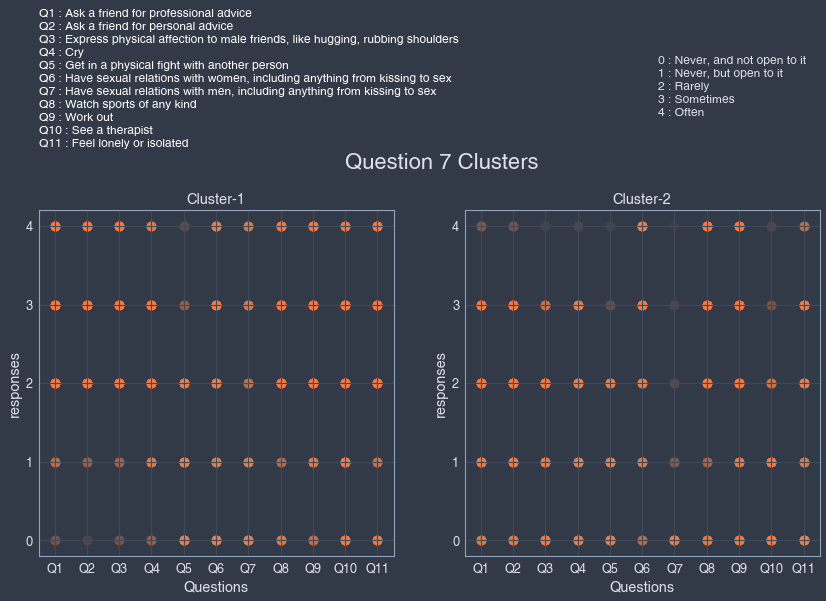

```python
plot_clusters(q0007_responses_to_cluster_1, q0007_responses_to_cluster_2, q0007_id, q0007_list, q0007_responses_list, 'Question 7 Clusters')
```

In the cluster-1, the sub-questions 6 and 7 responses data are very similar and equally distributed.  
In the cluster-2, the sub-questions 6 and 7 responses data are not similar, sub-question 7 as a significantly greater amount of `'Never, and not open to it'` responses than all other sub-question 7 responses.  
Sub-question 6, *'Have sexual relations with women, including anything from kissing to sex'*, is traditionally seen as masculine activities.  
On the other hand, sub-question 7, *'Have sexual relations with men, including anything from kissing to sex'*, is traditionally seen as feminine activities.  
When comparing both scatter plots graphs, sub-questions 6 and 7 response data, the men from cluster-1 seem more likely to express bi-sexual and homosexual activities than men from cluster-2.  
From the above findings, I classified the clusters as followed:

- Cluster-1, people expressing behaviors which are traditionally seen as feminine activities
- Cluster-2, people expressing behaviors which are traditionally seen as masculine activities

### + Separating the survey data by Clusters

Using the cluster results from question 7 responses, I separated the entire `'survey'` data by clusters.

#### - Modifying the survey_questions

Some of the features from the `'survey'` DataFrame, like `'kids'`, are not found in the `'survey_questions'` Series, I added a list of the those features to the `'survey_questions'` Series.

```python
print(f'"kids" feature response from the 100th survey: {survey["kids"][100]}\n')
print(f'- "q025_0001" response from the 100th survey: {survey["q0025_0001"][100]}\n')
print(f'- "q025_0002" response from the 100th survey: {survey["q0025_0002"][100]}\n')
print(f'- "q025_0003" response from the 100th survey: {survey["q0025_0003"][100]}\n')
```

```
"kids" feature response from the 100th survey: Has children

- "q025_0001" response from the 100th survey: Not selected

- "q025_0002" response from the 100th survey: Yes, one or more children 18 or older

- "q025_0003" response from the 100th survey: Not selected
```

```python
# Adding features to survey_questions
# Lists
missing_features_id = ['race2', 'racethn4', 'education', 'age3', 'kids', 'orientation', 'weight']
missing_features_description = ['Race', 'Race', 'Level of Education', 'Age', 'Children', 'Sexual Orientation', 'Weight']
# Creates a missing feature Series
missing_features = pd.Series(missing_features_description, index=missing_features_id)
# Adds
survey_questions = survey_questions.append(missing_features).rename('Survey Questions')
survey_questions.to_frame()
```

|  | Survey Questions |
| --- | --- |
| q0001 | In general, how masculine or “manly” do you feel? |
| q0002 | How important is it to you that others see you... |
| q0004 | Where have you gotten your ideas about what it... |
| q0005 | Do you think that society puts pressure on men... |
| q0007_0001 | Ask a friend for professional advice |
| q0007_0002 | Ask a friend for personal advice |
| q0007_0003 | Express physical affection to male friends, li... |
| q0007_0004 | Cry |
| q0007_0005 | Get in a physical fight with another person |
| q0007_0006 | Have sexual relations with women, including an... |
| q0007_0007 | Have sexual relations with men, including anyt... |
| q0007_0008 | Watch sports of any kind |
| q0007_0009 | Work out |
| q0007_0010 | See a therapist |
| q0007_0011 | Feel lonely or isolated |
| q0008 | Which of the following do you worry about on a... |
| q0009 | Which of the following categories best describ... |
| q0010 | In which of the following ways would you say i... |
| q0011 | In which of the following ways would you say i... |
| q0012 | Have you seen or heard of a sexual harassment ... |
| q0013 | And which of the following is the main reason ... |
| q0014 | How much have you heard about the #MeToo movem... |
| q0015 | As a man, would you say you think about your b... |
| q0017 | Do you typically feel as though you’re expecte... |
| q0018 | How often do you try to be the one who pays wh... |
| q0019 | Which of the following are reasons why you try... |
| q0020 | When you want to be physically intimate with s... |
| q0021 | Over the past 12 months, when it comes to sexu... |
| q0022 | Have you changed your behavior in romantic rel... |
| q0024 | Are you now married, widowed, divorced, separa... |
| q0025 | Do you have any children? |
| q0026 | Would you describe your sexual orientation as: |
| q0028 | Are you: |
| q0029 | What is the last grade of school you completed? |
| q0030 | What state do you live in? |
| q0034 | Income |
| q0035 | Time Zone |
| q0036 | Device |
| race2 | Race |
| racethn4 | Race |
| education | Level of Education |
| age3 | Age |
| kids | Children |
| orientation | Sexual Orientation |
| weight | Weight |

#### - Creating survey_questions DataFrame

```python
# Transforms the 'survey_questions' Series into a DataFrame with an 'q_id' column
survey_questions_df = survey_questions.reset_index().rename(columns={'index':'q_id'})
survey_questions_df.to_csv('data/survey_questions_df.csv')
survey_questions_df
```

|  | q_id | Survey Questions |
| --- | --- | --- |
| 0 | q0001 | In general, how masculine or “manly” do you feel? |
| 1 | q0002 | How important is it to you that others see you... |
| 2 | q0004 | Where have you gotten your ideas about what it... |
| 3 | q0005 | Do you think that society puts pressure on men... |
| 4 | q0007_0001 | Ask a friend for professional advice |
| 5 | q0007_0002 | Ask a friend for personal advice |
| 6 | q0007_0003 | Express physical affection to male friends, li... |
| 7 | q0007_0004 | Cry |
| 8 | q0007_0005 | Get in a physical fight with another person |
| 9 | q0007_0006 | Have sexual relations with women, including an... |
| 10 | q0007_0007 | Have sexual relations with men, including anyt... |
| 11 | q0007_0008 | Watch sports of any kind |
| 12 | q0007_0009 | Work out |
| 13 | q0007_0010 | See a therapist |
| 14 | q0007_0011 | Feel lonely or isolated |
| 15 | q0008 | Which of the following do you worry about on a... |
| 16 | q0009 | Which of the following categories best describ... |
| 17 | q0010 | In which of the following ways would you say i... |
| 18 | q0011 | In which of the following ways would you say i... |
| 19 | q0012 | Have you seen or heard of a sexual harassment ... |
| 20 | q0013 | And which of the following is the main reason ... |
| 21 | q0014 | How much have you heard about the #MeToo movem... |
| 22 | q0015 | As a man, would you say you think about your b... |
| 23 | q0017 | Do you typically feel as though you’re expecte... |
| 24 | q0018 | How often do you try to be the one who pays wh... |
| 25 | q0019 | Which of the following are reasons why you try... |
| 26 | q0020 | When you want to be physically intimate with s... |
| 27 | q0021 | Over the past 12 months, when it comes to sexu... |
| 28 | q0022 | Have you changed your behavior in romantic rel... |
| 29 | q0024 | Are you now married, widowed, divorced, separa... |
| 30 | q0025 | Do you have any children? |
| 31 | q0026 | Would you describe your sexual orientation as: |
| 32 | q0028 | Are you: |
| 33 | q0029 | What is the last grade of school you completed? |
| 34 | q0030 | What state do you live in? |
| 35 | q0034 | Income |
| 36 | q0035 | Time Zone |
| 37 | q0036 | Device |
| 38 | race2 | Race |
| 39 | racethn4 | Race |
| 40 | education | Level of Education |
| 41 | age3 | Age |
| 42 | kids | Children |
| 43 | orientation | Sexual Orientation |
| 44 | weight | Weight |

#### -Clusters DataFrames

I separated the `survey` data in two DataFrames, one containing the survey responses relative to cluster-1 and the other one to cluster-2.

```python
# Empty cluster DataFrames
cluster_1_df = pd.DataFrame()
cluster_2_df = pd.DataFrame()
# Separates Dataframe 'survey' by clusters
for q_id in survey_questions_df['q_id']:
    # Finds the question id corresponding responses ids in the survey DataFrame
    pattern = re.compile(q_id)
    responses_id = [col_name for col_name in survey.columns if pattern.match(col_name)]
    for r_id in responses_id:
        cluster_1_df[r_id] = [survey[r_id][i] for i in q0007_responses_to_cluster_1.index]
        cluster_2_df[r_id] = [survey[r_id][i] for i in q0007_responses_to_cluster_2.index]

cluster_1_df.to_csv('data/cluster_1_df.csv')
cluster_2_df.to_csv('data/cluster_2_df.csv')
cluster_1_df
```

|  | q0001 | q0002 | q0004_0001 | q0004_0002 | q0004_0003 | q0004_0004 | q0004_0005 | q0004_0006 | q0005 | q0007_0001 | ... | q0034 | q0035 | q0036 | race2 | racethn4 | education | age3 | kids | orientation | weight |
| --- | --- | --- | --- | --- | --- | --- | --- | --- | --- | --- | --- | --- | --- | --- | --- | --- | --- | --- | --- | --- | --- |
| 0 | Somewhat masculine | Somewhat important | Not selected | Not selected | Not selected | Pop culture | Not selected | Not selected | Yes | Often | ... | $0-$9,999 | Middle Atlantic | Windows Desktop / Laptop | Non-white | Hispanic | College or more | 35 - 64 | No children | Gay/Bisexual | 1.71402597 |
| 1 | Very masculine | Not too important | Father or father figure(s) | Not selected | Not selected | Not selected | Not selected | Other (please specify) | No | Sometimes | ... | $50,000-$74,999 | East North Central | Windows Desktop / Laptop | White | White | College or more | 35 - 64 | Has children | Straight | 0.51574606 |
| 2 | Very masculine | Somewhat important | Father or father figure(s) | Not selected | Not selected | Not selected | Not selected | Not selected | Yes | Never, but open to it | ... | $200,000+ | East North Central | Windows Desktop / Laptop | White | White | Post graduate degree | 65 and up | Has children | Straight | 0.05908664 |
| 3 | Very masculine | Not at all important | Father or father figure(s) | Not selected | Not selected | Not selected | Friends | Not selected | No | Sometimes | ... | $100,000-$124,999 | Pacific | iOS Phone / Tablet | Non-white | Hispanic | Some college | 35 - 64 | Has children | Straight | 4.34185025 |
| 4 | Somewhat masculine | Not too important | Father or father figure(s) | Not selected | Not selected | Not selected | Not selected | Not selected | Yes | Never, but open to it | ... | $25,000-$49,999 | South Atlantic | Other | White | White | Some college | 35 - 64 | No children | Straight | 0.61790602 |
| ... | ... | ... | ... | ... | ... | ... | ... | ... | ... | ... | ... | ... | ... | ... | ... | ... | ... | ... | ... | ... | ... |
| 637 | Somewhat masculine | Somewhat important | Father or father figure(s) | Mother or mother figure(s) | Other family members | Pop culture | Friends | Not selected | Yes | Often | ... | Prefer not to answer | Pacific | Windows Desktop / Laptop | White | White | Some college | 18 - 34 | No children | Other | 1.86202013 |
| 638 | Very masculine | Not at all important | Father or father figure(s) | Mother or mother figure(s) | Other family members | Pop culture | Not selected | Not selected | Yes | Rarely | ... | $100,000-$124,999 | East North Central | iOS Phone / Tablet | White | White | Some college | 65 and up | Has children | Straight | 0.60064008 |
| 639 | Very masculine | Not at all important | Father or father figure(s) | Not selected | Not selected | Not selected | Not selected | Not selected | No | Often | ... | Prefer not to answer | Middle Atlantic | MacOS Desktop / Laptop | White | White | College or more | 35 - 64 | Has children | Straight | 0.70666089 |
| 640 | Somewhat masculine | Somewhat important | Not selected | Not selected | Not selected | Not selected | Not selected | Other (please specify) | Yes | Sometimes | ... | Prefer not to answer | New England | Windows Desktop / Laptop | White | White | High school or less | 35 - 64 | Has children | Straight | 2.44671888 |
| 641 | Very masculine | Very important | Father or father figure(s) | Mother or mother figure(s) | Not selected | Not selected | Not selected | Not selected | No | Often | ... | $100,000-$124,999 | Pacific | iOS Phone / Tablet | White | White | Some college | 65 and up | Has children | Straight | 0.61517971 |

642 rows × 94 columns

## **▪ Investigating the Cluster Members**

I investigated the `survey`'s features:

by looking at the following questions responses percentages,

- `q0004`, *where have you gotten your ideas about what it means to be a good man?*
- `q0010`, *in which of the following ways would you say it’s an* advantage *to be a man at your work right now?*
- `q0011`, *in which of the following ways would you say it’s a* disadvantage *to be a man at your work right now?*

by answering the following question,

- which demographic features have stronger correlations with ideas of masculinity (sexual orientation, age, race, marital status, parenthood?)

Note, earlier I classified the clusters as followed:

- Cluster-1, people expressing behaviors which are traditionally seen as feminine activities
- Cluster-2, people expressing behaviors which are traditionally seen as masculine activities

### + The investigate_member() function

The function returns a question percentages of responses, per selectable responses, and by cluster.

#### - The argument member

The function takes the argument `member`, it is a question id number, from the `survey_question['q_id']` Dataframe.

#### - The function

The function, `investigate_member()`, returns the percentages of responses for the inputted question, per selectable responses, and by cluster.

- Takes the arguments:
  - member, a string data type
  - cluster_1, a DataFrame data type defaulted to cluster_1_df
  - cluster_2, a DataFrame data type defaulted to cluster_2_df
  - survey, a DataFrame data type defaulted to survey
- Computes the member percentages of responses, per selectable responses, and by cluster
- Returns a DataFrame of the percentages of responses, per selectable responses, and by cluster

```python
def investigate_member(member, cluster_1=cluster_1_df, cluster_2=cluster_2_df, survey=survey):
    # Finds the member corresponding responses reference in the survey DataFrame
    pattern = re.compile(member)
    responses_id = [col_name for col_name in survey.columns if pattern.match(col_name)]
    # Empty ivestagation DataFrame
    investigation = pd.DataFrame()
    # Response 'weight'
    if member == 'weight':
        investigation['cluster_1'] = [cluster_1['weight'].mean()]
        investigation['cluster_2'] = [cluster_2['weight'].mean()]
    # Responses
    else:
        # Calculates the question percentages of responses, per responses part, and by cluster
        for r_id in responses_id:
            # Empty response part DataFrame
            inv = pd.DataFrame()
            # Calculates saves percentages
            inv['cluster_1'] = cluster_1[r_id].value_counts()/len(cluster_1_df[r_id])
            inv['cluster_2'] = cluster_2[r_id].value_counts()/len(cluster_2_df[r_id])
            # Creates a new index list and keeps the old index list
            inv = inv.reset_index()
            # Removed the response part not selected percentages
            inv = inv[inv['index'] != 'Not selected']
            # Add the response part percentages to the main DataFrame
            investigation = pd.concat([investigation, inv], axis=0).reset_index(drop=True)
    # Renames the column index to the question sentence and creates a new index list
    question = survey_questions_df['Survey Questions'][survey_questions_df['q_id'] == member].values[0]
    investigation = investigation.rename(columns={'index':question}).reset_index()
    # Renames the column index to 'member'
    investigation = investigation.rename(columns={'index':member})
    return investigation
```

### + Responses investigation results

```python
investigate_member('q0004').style.hide_index()
```

| q0004 | Where have you gotten your ideas about what it means to be a good man? | cluster_1 | cluster_2 |
| --- | --- | --- | --- |
| 0 | Father or father figure(s) | 0.70249221 | 0.65879265 |
| 1 | Mother or mother figure(s) | 0.40498442 | 0.38582677 |
| 2 | Other family members | 0.37383178 | 0.28608924 |
| 3 | Pop culture | 0.20716511 | 0.13648294 |
| 4 | Friends | 0.39408100 | 0.26509186 |
| 5 | Other (please specify) | 0.22118380 | 0.20209974 |

The people from cluster-1, seem to get their *ideas about what it means to be a good man* more from other than people from cluster-2.

```python
investigate_member('q0010').style.hide_index()
```

| q0010 | In which of the following ways would you say it’s an advantage to be a man at your work right now? | cluster_1 | cluster_2 |
| --- | --- | --- | --- |
| 0 | Men make more money | 0.11526480 | 0.06036745 |
| 1 | Men are taken more seriously | 0.14330218 | 0.08398950 |
| 2 | Men have more choice | 0.07943925 | 0.05511811 |
| 3 | Men have more promotion/professional development opportunities | 0.09501558 | 0.06036745 |
| 4 | Men are explicitly praised more often | 0.03894081 | 0.02362205 |
| 5 | Men generally have more support from their managers | 0.05140187 | 0.04461942 |
| 6 | None of the above | 0.27881620 | 0.31758530 |
| 7 | Other (please specify) | 0.04205607 | 0.03149606 |

The people from cluster-1 expressed more than people from cluster-2, that bean a man in their workplace has financial and leadership advantages.

```python
investigate_member('q0011').style.hide_index()
```

| q0011 | In which of the following ways would you say it’s a disadvantage to be a man at your work right now? | cluster_1 | cluster_2 |
| --- | --- | --- | --- |
| 0 | Managers want to hire and promote women | 0.10903427 | 0.07874016 |
| 1 | Greater risk of being accused of sexual harassment | 0.25700935 | 0.20734908 |
| 2 | Greater risk of being accused of being sexist or racist | 0.24766355 | 0.18110236 |
| 3 | None of the above | 0.17445483 | 0.18372703 |
| 4 | Other (please specify) | 0.02647975 | 0.02362205 |

The people from cluster-1 expressed more than the people from cluster-2 that men in their workplace are more likely to have their position at work frightened by management wanting to hire and promote women, and men are more likely at risk to be accused of sexual harassment, being sexist or racist.

### + Answering the demographic question

In the `'survey_questions_df'`, the demographic features are found from the indexes 29, `'q0024'`, to 44, `'weight'`.

```python
survey_questions_df[29:]
```

|  | q_id | Survey Questions |
| --- | --- | --- |
| 29 | q0024 | Are you now married, widowed, divorced, separa... |
| 30 | q0025 | Do you have any children? |
| 31 | q0026 | Would you describe your sexual orientation as: |
| 32 | q0028 | Are you: |
| 33 | q0029 | What is the last grade of school you completed? |
| 34 | q0030 | What state do you live in? |
| 35 | q0034 | Income |
| 36 | q0035 | Time Zone |
| 37 | q0036 | Device |
| 38 | race2 | Race |
| 39 | racethn4 | Race |
| 40 | education | Level of Education |
| 41 | age3 | Age |
| 42 | kids | Children |
| 43 | orientation | Sexual Orientation |
| 44 | weight | Weight |

Some of the demographic features are closely related like `'q0025'`, *'Do you have any children?'*, and `'kid'`, *'Children'*. For this exercise, I decided not to some of related features.

```python
demographic_survey_questions = survey_questions_df[29:].drop([31, 39, 40, 42])
demographic_survey_questions
```

|  | q_id | Survey Questions |
| --- | --- | --- |
| 29 | q0024 | Are you now married, widowed, divorced, separa... |
| 30 | q0025 | Do you have any children? |
| 32 | q0028 | Are you: |
| 33 | q0029 | What is the last grade of school you completed? |
| 34 | q0030 | What state do you live in? |
| 35 | q0034 | Income |
| 36 | q0035 | Time Zone |
| 37 | q0036 | Device |
| 38 | race2 | Race |
| 41 | age3 | Age |
| 43 | orientation | Sexual Orientation |
| 44 | weight | Weight |

#### - Demographic features correlation with the *traditional* ideas of masculinity, Cluster-2

In this section, I analyzed the demographic features correlation with *traditional* ideas of masculinity by isolating the cluster-2 higher than cluster-1 features investigation results, and by calculating the difference between the two.

```python
# Creates an empty cluster-2  demographic analysis DataFrame
analysis_demographic_c2 = pd.DataFrame(columns=['id', 'reponses', 'cluster_1', 'cluster_2'])
# Finds demographic survey questions responses
for q_id in demographic_survey_questions['q_id']:
    # Calculates percentages, features investigation results
    an_demographic = investigate_member(q_id)
    # Compares features investigation and saves results
    for i in range(len(an_demographic)):
        # Compares features investigation results results
        if an_demographic['cluster_1'][i] < an_demographic['cluster_2'][i]:
            # Finds the responses 'id' and store the values to used as a columns name
            values = [an_demographic.columns[0]] + an_demographic.loc[i][1:].values.tolist()
            # Stores comparison results
            analysis_demographic_c2 = analysis_demographic_c2.append(dict(zip(analysis_demographic_c2.columns, values)),
                                                                     ignore_index=True)
    # Calculates the difference between the cluster-2 higher than cluster-1 features investigation results
    analysis_demographic_c2['Diff'] = analysis_demographic_c2['cluster_2'] - analysis_demographic_c2['cluster_1']
# Sorts by Difference values
analysis_demographic_c2 = analysis_demographic_c2.sort_values(by=['Diff'], ascending=False)

analysis_demographic_c2.to_csv('data/analysis_demographic_c2.csv')
analysis_demographic_c2.head(10).style.hide_index()
```

| id | reponses | cluster_1 | cluster_2 | Diff |
| --- | --- | --- | --- | --- |
| orientation | Straight | 0.82242991 | 0.94488189 | 0.12245198 |
| age3 | 65 and up | 0.42367601 | 0.53805774 | 0.11438173 |
| q0036 | Windows Desktop / Laptop | 0.50778816 | 0.59580052 | 0.08801236 |
| q0025 | Yes, one or more children 18 or older | 0.55763240 | 0.63517060 | 0.07753820 |
| q0024 | Married | 0.60436137 | 0.67979003 | 0.07542866 |
| q0029 | Some college | 0.14641745 | 0.20472441 | 0.05830696 |
| q0034 | $50,000-$74,999 | 0.14174455 | 0.18635171 | 0.04460716 |
| q0029 | High school or G.E.D. | 0.07165109 | 0.11286089 | 0.04120980 |
| q0036 | Android Phone / Tablet | 0.12928349 | 0.16535433 | 0.03607084 |
| q0030 | Florida | 0.06230530 | 0.09711286 | 0.03480756 |

The demographic features having the strongest correlations with the ideas of *traditional* masculinity are:

- straight men over 65 years old that use windows desktops or/and laptops as personal computers, and have children over 18 years old.

#### - Demographic features correlation with the *non-traditional* ideas of masculinity, Cluster-1

In this section, I analyzed the demographic features correlation with *non-traditional* ideas of masculinity by isolating the cluster-1 higher than cluster-2 features investigation results, and by calculating the difference between the two.

```python
# Creates an empty cluster-1 demographic analysis DataFrame
analysis_demographic_c1 = pd.DataFrame(columns=['id', 'reponses', 'cluster_1', 'cluster_2'])
# Finds demographic survey questions responses
for q_id in demographic_survey_questions['q_id']:
    # Calculates percentages, features investigation results
    an_demographic = investigate_member(q_id)
    # Compares features investigation and saves results
    for i in range(len(an_demographic)):
        # Compares features investigation results results
        if an_demographic['cluster_1'][i] > an_demographic['cluster_2'][i]:
            # Finds the responses 'id' and store the values to used as a columns name
            values = [an_demographic.columns[0]] + an_demographic.loc[i][1:].values.tolist()
            # Stores comparison results
            analysis_demographic_c1 = analysis_demographic_c1.append(dict(zip(analysis_demographic_c1.columns, values)),
                                                                     ignore_index=True)
     # Calculates the difference between the cluster-1 higher than cluster-2 features investigation results
    analysis_demographic_c1['Diff'] = analysis_demographic_c1['cluster_1'] - analysis_demographic_c1['cluster_2']
# Sorts by Difference values
analysis_demographic_c1 = analysis_demographic_c1.sort_values(by=['Diff'], ascending=False)

analysis_demographic_c1.to_csv('data/analysis_demographic_c1.csv')
analysis_demographic_c1.head(10).style.hide_index()
```

| id | reponses | cluster_1 | cluster_2 | Diff |
| --- | --- | --- | --- | --- |
| q0029 | Post graduate degree | 0.36915888 | 0.25721785 | 0.11194103 |
| orientation | Gay/Bisexual | 0.15109034 | 0.03937008 | 0.11172026 |
| age3 | 35 - 64 | 0.50311526 | 0.40419948 | 0.09891579 |
| q0036 | iOS Phone / Tablet | 0.21962617 | 0.16010499 | 0.05952118 |
| q0024 | Never married | 0.16978193 | 0.11548556 | 0.05429637 |
| q0036 | MacOS Desktop / Laptop | 0.11838006 | 0.06561680 | 0.05276326 |
| q0025 | Yes, one or more children under 18 | 0.15264798 | 0.10498688 | 0.04766110 |
| q0025 | No children | 0.33021807 | 0.29396325 | 0.03625481 |
| q0034 | $75,000-$99,999 | 0.16043614 | 0.12860892 | 0.03182721 |
| q0024 | Divorced | 0.14797508 | 0.12073491 | 0.02724017 |

The demographic features having the strongest correlations with the ideas of *non-traditional* masculinity are:

- Gay or bisexual post graduate degree men between 35-64 years old that use iOS phones or/and tablets.

### + All the features investigation results

The following code cell outputs all the features investigation results, if you are interested to take a look at it.

```python
for q_id in survey_questions_df['q_id']:
    investigation = investigate_member(q_id)
    # Saves
    question_id = investigation.columns[0]
    # As a .csv file
    investigation.to_csv(f'data/inv_{question_id}.csv')
    # As a .html file
    with open(f'html_DataFrames/inv_{question_id}.html', 'w') as f:
        f.write(HTML(investigation.style.hide_index().render()).data)
    # Displays
    display(investigation.style.hide_index().set_properties(subset=[question_id],**{'text-align': 'center'}))
```

| q0001 | In general, how masculine or “manly” do you feel? | cluster_1 | cluster_2 |
| --- | --- | --- | --- |
| 0 | Somewhat masculine | 0.54517134 | 0.48556430 |
| 1 | Very masculine | 0.36604361 | 0.38582677 |
| 2 | Not very masculine | 0.07320872 | 0.09448819 |
| 3 | Not at all masculine | 0.01246106 | 0.01837270 |
| 4 | No answer | 0.00311526 | 0.01574803 |

| q0002 | How important is it to you that others see you as masculine? | cluster_1 | cluster_2 |
| --- | --- | --- | --- |
| 0 | Somewhat important | 0.39875389 | 0.36745407 |
| 1 | Not too important | 0.35514019 | 0.32020997 |
| 2 | Not at all important | 0.13551402 | 0.17847769 |
| 3 | Very important | 0.10591900 | 0.13385827 |
| 4 | No answer | 0.00467290 | nan |

| q0004 | Where have you gotten your ideas about what it means to be a good man? | cluster_1 | cluster_2 |
| --- | --- | --- | --- |
| 0 | Father or father figure(s) | 0.70249221 | 0.65879265 |
| 1 | Mother or mother figure(s) | 0.40498442 | 0.38582677 |
| 2 | Other family members | 0.37383178 | 0.28608924 |
| 3 | Pop culture | 0.20716511 | 0.13648294 |
| 4 | Friends | 0.39408100 | 0.26509186 |
| 5 | Other (please specify) | 0.22118380 | 0.20209974 |

| q0005 | Do you think that society puts pressure on men in a way that is unhealthy or badfor them? | cluster_1 | cluster_2 |
| --- | --- | --- | --- |
| 0 | Yes | 0.64018692 | 0.46194226 |
| 1 | No | 0.35825545 | 0.53018373 |
| 2 | No answer | 0.00155763 | 0.00787402 |

| q0007_0001 | Ask a friend for professional advice | cluster_1 | cluster_2 |
| --- | --- | --- | --- |
| 0 | Sometimes | 0.55763240 | 0.28608924 |
| 1 | Rarely | 0.21183801 | 0.35695538 |
| 2 | Often | 0.18068536 | 0.02624672 |
| 3 | Never, but open to it | 0.03738318 | 0.23097113 |
| 4 | Never, and not open to it | 0.01246106 | 0.09973753 |

| q0007_0002 | Ask a friend for personal advice | cluster_1 | cluster_2 |
| --- | --- | --- | --- |
| 0 | Sometimes | 0.55919003 | 0.22834646 |
| 1 | Rarely | 0.26012461 | 0.43832021 |
| 2 | Often | 0.15420561 | 0.02099738 |
| 3 | Never, but open to it | 0.02180685 | 0.20472441 |
| 4 | Never, and not open to it | 0.00467290 | 0.10761155 |

| q0007_0003 | Express physical affection to male friends, like hugging, rubbing shoulders | cluster_1 | cluster_2 |
| --- | --- | --- | --- |
| 0 | Sometimes | 0.44236760 | 0.07086614 |
| 1 | Rarely | 0.29595016 | 0.28346457 |
| 2 | Often | 0.22429907 | 0.00524934 |
| 3 | Never, but open to it | 0.02492212 | 0.16010499 |
| 4 | Never, and not open to it | 0.01246106 | 0.48031496 |

| q0007_0004 | Cry | cluster_1 | cluster_2 |
| --- | --- | --- | --- |
| 0 | Rarely | 0.43302181 | 0.48818898 |
| 1 | Sometimes | 0.42679128 | 0.15748031 |
| 2 | Never, but open to it | 0.06230530 | 0.18897638 |
| 3 | Often | 0.05763240 | 0.00787402 |
| 4 | Never, and not open to it | 0.02024922 | 0.15748031 |

| q0007_0005 | Get in a physical fight with another person | cluster_1 | cluster_2 |
| --- | --- | --- | --- |
| 0 | Never, and not open to it | 0.56386293 | 0.64566929 |
| 1 | Rarely | 0.21806854 | 0.13648294 |
| 2 | Never, but open to it | 0.19003115 | 0.19685039 |
| 3 | Sometimes | 0.02024922 | 0.01574803 |
| 4 | Often | 0.00778816 | 0.00524934 |

| q0007_0006 | Have sexual relations with women, including anything from kissing to sex | cluster_1 | cluster_2 |
| --- | --- | --- | --- |
| 0 | Often | 0.34890966 | 0.38845144 |
| 1 | Sometimes | 0.34112150 | 0.31758530 |
| 2 | Rarely | 0.12772586 | 0.13910761 |
| 3 | Never, and not open to it | 0.11214953 | 0.05774278 |
| 4 | Never, but open to it | 0.07009346 | 0.09711286 |

| q0007_0007 | Have sexual relations with men, including anything from kissing to sex | cluster_1 | cluster_2 |
| --- | --- | --- | --- |
| 0 | Never, and not open to it | 0.78348910 | 0.95013123 |
| 1 | Never, but open to it | 0.07009346 | 0.02887139 |
| 2 | Often | 0.05451713 | 0.00262467 |
| 3 | Sometimes | 0.05295950 | 0.00787402 |
| 4 | Rarely | 0.03894081 | 0.01049869 |

| q0007_0008 | Watch sports of any kind | cluster_1 | cluster_2 |
| --- | --- | --- | --- |
| 0 | Often | 0.41277259 | 0.39107612 |
| 1 | Sometimes | 0.29127726 | 0.29921260 |
| 2 | Rarely | 0.20716511 | 0.14960630 |
| 3 | Never, and not open to it | 0.05607477 | 0.11548556 |
| 4 | Never, but open to it | 0.03271028 | 0.04461942 |

| q0007_0009 | Work out | cluster_1 | cluster_2 |
| --- | --- | --- | --- |
| 0 | Sometimes | 0.33021807 | 0.25459318 |
| 1 | Often | 0.30685358 | 0.16535433 |
| 2 | Rarely | 0.26168224 | 0.31496063 |
| 3 | Never, but open to it | 0.06230530 | 0.12335958 |
| 4 | Never, and not open to it | 0.03894081 | 0.14173228 |

| q0007_0010 | See a therapist | cluster_1 | cluster_2 |
| --- | --- | --- | --- |
| 0 | Never, but open to it | 0.42367601 | 0.36482940 |
| 1 | Rarely | 0.22118380 | 0.07611549 |
| 2 | Never, and not open to it | 0.15732087 | 0.53018373 |
| 3 | Sometimes | 0.12149533 | 0.02099738 |
| 4 | Often | 0.07632399 | 0.00787402 |

| q0007_0011 | Feel lonely or isolated | cluster_1 | cluster_2 |
| --- | --- | --- | --- |
| 0 | Rarely | 0.42834891 | 0.33070866 |
| 1 | Sometimes | 0.33800623 | 0.22047244 |
| 2 | Often | 0.11993769 | 0.06299213 |
| 3 | Never, and not open to it | 0.07165109 | 0.29133858 |
| 4 | Never, but open to it | 0.04205607 | 0.09448819 |

| q0008 | Which of the following do you worry about on a daily or near daily basis? | cluster_1 | cluster_2 |
| --- | --- | --- | --- |
| 0 | Your height | 0.04361371 | 0.02099738 |
| 1 | Your weight | 0.60747664 | 0.46194226 |
| 2 | Your hair or hairline | 0.13707165 | 0.06824147 |
| 3 | Your physique | 0.35981308 | 0.20734908 |
| 4 | Appearance of your genitalia | 0.08878505 | 0.06299213 |
| 5 | Your clothing or style | 0.12149533 | 0.08661417 |
| 6 | Sexual performance or amount of sex | 0.24299065 | 0.16272966 |
| 7 | Your mental health | 0.25545171 | 0.18897638 |
| 8 | Your physical health | 0.56230530 | 0.47506562 |
| 9 | Your finances, including your current or future income, assets, or debt | 0.49376947 | 0.38320210 |
| 10 | Your ability to provide for your family, current or anticipated | 0.28971963 | 0.20734908 |
| 11 | None of the above | 0.12616822 | 0.23359580 |

| q0009 | Which of the following categories best describes your employment status? | cluster_1 | cluster_2 |
| --- | --- | --- | --- |
| 0 | Employed, working full-time | 0.42211838 | 0.37795276 |
| 1 | Not employed-retired | 0.36915888 | 0.41994751 |
| 2 | Employed, working part-time | 0.09034268 | 0.09448819 |
| 3 | Not employed, NOT looking for work | 0.06074766 | 0.07349081 |
| 4 | Not employed, looking for work | 0.03894081 | 0.02362205 |
| 5 | Not employed, student | 0.01869159 | 0.01049869 |

| q0010 | In which of the following ways would you say it’s an advantage to be a man at your work right now? | cluster_1 | cluster_2 |
| --- | --- | --- | --- |
| 0 | Men make more money | 0.11526480 | 0.06036745 |
| 1 | Men are taken more seriously | 0.14330218 | 0.08398950 |
| 2 | Men have more choice | 0.07943925 | 0.05511811 |
| 3 | Men have more promotion/professional development opportunities | 0.09501558 | 0.06036745 |
| 4 | Men are explicitly praised more often | 0.03894081 | 0.02362205 |
| 5 | Men generally have more support from their managers | 0.05140187 | 0.04461942 |
| 6 | None of the above | 0.27881620 | 0.31758530 |
| 7 | Other (please specify) | 0.04205607 | 0.03149606 |

| q0011 | In which of the following ways would you say it’s a disadvantage to be a man at your work right now? | cluster_1 | cluster_2 |
| --- | --- | --- | --- |
| 0 | Managers want to hire and promote women | 0.10903427 | 0.07874016 |
| 1 | Greater risk of being accused of sexual harassment | 0.25700935 | 0.20734908 |
| 2 | Greater risk of being accused of being sexist or racist | 0.24766355 | 0.18110236 |
| 3 | None of the above | 0.17445483 | 0.18372703 |
| 4 | Other (please specify) | 0.02647975 | 0.02362205 |

| q0012 | Have you seen or heard of a sexual harassment incident at your work? If so, how did you respond? | cluster_1 | cluster_2 |
| --- | --- | --- | --- |
| 0 | Confronted the accused person | 0.03738318 | 0.00787402 |
| 1 | Contacted the HR department | 0.03582555 | 0.04724409 |
| 2 | Contacted the manager of the accused person | 0.02803738 | 0.02362205 |
| 3 | Reached out to the victim to offer support | 0.05295950 | 0.03674541 |
| 4 | Did not respond at all | 0.02024922 | 0.03937008 |
| 5 | Never witnessed sexual harassment | 0.37071651 | 0.34383202 |
| 6 | Other (please specify) | 0.02180685 | 0.01574803 |

| q0013 | And which of the following is the main reason you did not respond? | cluster_1 | cluster_2 |
| --- | --- | --- | --- |
| 0 | You weren?t sure it was sexual harassment | 0.00778816 | 0.01049869 |
| 1 | You didn?t want to get involved | 0.00778816 | 0.00262467 |
| 2 | You didn?t think it was your place | 0.00311526 | 0.02099738 |
| 3 | No answer | 0.00155763 | nan |

| q0014 | How much have you heard about the #MeToo movement? | cluster_1 | cluster_2 |
| --- | --- | --- | --- |
| 0 | A lot | 0.27258567 | 0.16535433 |
| 1 | Some | 0.13395639 | 0.13648294 |
| 2 | Nothing at all | 0.06853583 | 0.10761155 |
| 3 | Only a little | 0.03738318 | 0.06299213 |

| q0015 | As a man, would you say you think about your behavior at work differently in the wake of #MeToo? | cluster_1 | cluster_2 |
| --- | --- | --- | --- |
| 0 | No | 0.28348910 | 0.28608924 |
| 1 | Yes | 0.15420561 | 0.07874016 |
| 2 | No answer | 0.00623053 | nan |

| q0017 | Do you typically feel as though you’re expected to make the first move in romantic relationships? | cluster_1 | cluster_2 |
| --- | --- | --- | --- |
| 0 | Yes | 0.66355140 | 0.57217848 |
| 1 | No | 0.32242991 | 0.41469816 |
| 2 | No answer | 0.01401869 | 0.01312336 |

| q0018 | How often do you try to be the one who pays when on a date? | cluster_1 | cluster_2 |
| --- | --- | --- | --- |
| 0 | Always | 0.48286604 | 0.54068241 |
| 1 | Often | 0.29906542 | 0.23884514 |
| 2 | Sometimes | 0.15420561 | 0.10236220 |
| 3 | Never | 0.02959502 | 0.07874016 |
| 4 | Rarely | 0.01713396 | 0.01049869 |
| 5 | No answer | 0.01713396 | 0.02887139 |

| q0019 | Which of the following are reasons why you try to pay when on a date? | cluster_1 | cluster_2 |
| --- | --- | --- | --- |
| 0 | It?s the right thing to do | 0.52803738 | 0.52230971 |
| 1 | You make more money than your date | 0.14330218 | 0.09186352 |
| 2 | You feel good about being the one who pays | 0.30062305 | 0.21522310 |
| 3 | Societal expectations, even though you don?t always think you should have to pay | 0.23520249 | 0.18897638 |
| 4 | You asked the person out, so you feel obligated to pay | 0.43613707 | 0.39632546 |
| 5 | You try to pay to see if the other person will offer to share in the cost | 0.03894081 | 0.04199475 |
| 6 | Other (please specify) | 0.06542056 | 0.08398950 |

| q0020 | When you want to be physically intimate with someone, how do you gauge their interest? | cluster_1 | cluster_2 |
| --- | --- | --- | --- |
| 0 | Read their physical body language to see if they are interested | 0.48753894 | 0.38320210 |
| 1 | Ask for a verbal confirmation of consent | 0.30996885 | 0.23097113 |
| 2 | Make a physical move to see how they react | 0.27881620 | 0.25459318 |
| 3 | Every situation is different | 0.64641745 | 0.58267717 |
| 4 | It isn?t always clear how to gauge someone?s interest | 0.38785047 | 0.34383202 |
| 5 | Other (please specify) | 0.07788162 | 0.09711286 |

| q0021 | Over the past 12 months, when it comes to sexual boundaries, which of the following things have you done? | cluster_1 | cluster_2 |
| --- | --- | --- | --- |
| 0 | Wondered whether you pushed a partner too far in a past sexual encounter. | 0.09501558 | 0.04724409 |
| 1 | Talked with a friend or friends about whether you pushed a partner too far. | 0.01869159 | 0.00787402 |
| 2 | Contacted a past sexual partner to ask whether you went too far in any of you sexual encounters. | 0.01713396 | 0.01312336 |
| 3 | None of the above | 0.87383178 | 0.92650919 |

| q0022 | Have you changed your behavior in romantic relationships in the wake of #MeToo movement? | cluster_1 | cluster_2 |
| --- | --- | --- | --- |
| 0 | No | 0.90031153 | 0.93438320 |
| 1 | Yes | 0.09501558 | 0.04986877 |
| 2 | No answer | 0.00467290 | 0.01574803 |

| q0024 | Are you now married, widowed, divorced, separated, or have you neverbeen married? | cluster_1 | cluster_2 |
| --- | --- | --- | --- |
| 0 | Married | 0.60436137 | 0.67979003 |
| 1 | Never married | 0.16978193 | 0.11548556 |
| 2 | Divorced | 0.14797508 | 0.12073491 |
| 3 | Widowed | 0.06074766 | 0.06824147 |
| 4 | Separated | 0.01557632 | 0.01049869 |
| 5 | No answer | 0.00155763 | 0.00524934 |

| q0025 | Do you have any children? | cluster_1 | cluster_2 |
| --- | --- | --- | --- |
| 0 | Yes, one or more children under 18 | 0.15264798 | 0.10498688 |
| 1 | Yes, one or more children 18 or older | 0.55763240 | 0.63517060 |
| 2 | No children | 0.33021807 | 0.29396325 |

| q0026 | Would you describe your sexual orientation as: | cluster_1 | cluster_2 |
| --- | --- | --- | --- |
| 0 | Straight | 0.82242991 | 0.94750656 |
| 1 | Gay | 0.10591900 | 0.02099738 |
| 2 | Bisexual | 0.04517134 | 0.01837270 |
| 3 | Other | 0.02492212 | 0.00787402 |
| 4 | No answer | 0.00155763 | 0.00524934 |

| q0028 | Are you: | cluster_1 | cluster_2 |
| --- | --- | --- | --- |
| 0 | White | 0.84890966 | 0.85301837 |
| 1 | Other | 0.06074766 | 0.05774278 |
| 2 | Hispanic | 0.04049844 | 0.03149606 |
| 3 | Black | 0.02803738 | 0.04199475 |
| 4 | Asian | 0.02180685 | 0.01574803 |

| q0029 | What is the last grade of school you completed? | cluster_1 | cluster_2 |
| --- | --- | --- | --- |
| 0 | Post graduate degree | 0.36915888 | 0.25721785 |
| 1 | College graduate | 0.31308411 | 0.32020997 |
| 2 | Some college | 0.14641745 | 0.20472441 |
| 3 | Associate's degree | 0.09034268 | 0.08923885 |
| 4 | High school or G.E.D. | 0.07165109 | 0.11286089 |
| 5 | Did not complete high school | 0.00934579 | 0.01574803 |

| q0030 | What state do you live in? | cluster_1 | cluster_2 |
| --- | --- | --- | --- |
| 0 | California | 0.12616822 | 0.11811024 |
| 1 | Texas | 0.07788162 | 0.06561680 |
| 2 | New York | 0.07632399 | 0.04986877 |
| 3 | Florida | 0.06230530 | 0.09711286 |
| 4 | Pennsylvania | 0.04672897 | 0.04724409 |
| 5 | Illinois | 0.04517134 | 0.02362205 |
| 6 | Washington | 0.04049844 | 0.04199475 |
| 7 | Georgia | 0.03115265 | 0.02887139 |
| 8 | Michigan | 0.02803738 | 0.03149606 |
| 9 | New Jersey | 0.02803738 | 0.02887139 |
| 10 | Arizona | 0.02492212 | 0.03674541 |
| 11 | Wisconsin | 0.02492212 | 0.01837270 |
| 12 | Oregon | 0.02336449 | 0.03674541 |
| 13 | Massachusetts | 0.02336449 | 0.01837270 |
| 14 | Colorado | 0.02336449 | 0.00787402 |
| 15 | Virginia | 0.02180685 | 0.02362205 |
| 16 | Ohio | 0.02180685 | 0.02362205 |
| 17 | North Carolina | 0.02024922 | 0.01574803 |
| 18 | Minnesota | 0.02024922 | 0.02099738 |
| 19 | Indiana | 0.01869159 | 0.01837270 |
| 20 | Maryland | 0.01713396 | 0.01837270 |
| 21 | Missouri | 0.01557632 | 0.02624672 |
| 22 | South Carolina | 0.01401869 | 0.00524934 |
| 23 | Kentucky | 0.01246106 | 0.00524934 |
| 24 | New Mexico | 0.01090343 | 0.00524934 |
| 25 | Kansas | 0.01090343 | 0.00524934 |
| 26 | Utah | 0.01090343 | 0.01837270 |
| 27 | Iowa | 0.00934579 | 0.00787402 |
| 28 | Tennessee | 0.00934579 | 0.01312336 |
| 29 | Vermont | 0.00934579 | nan |
| 30 | Delaware | 0.00778816 | nan |
| 31 | Hawaii | 0.00778816 | 0.00524934 |
| 32 | Idaho | 0.00778816 | 0.00524934 |
| 33 | Nevada | 0.00778816 | 0.02624672 |
| 34 | Louisiana | 0.00778816 | 0.01049869 |
| 35 | West Virginia | 0.00623053 | 0.00787402 |
| 36 | Connecticut | 0.00623053 | 0.01837270 |
| 37 | Alabama | 0.00623053 | 0.01312336 |
| 38 | Maine | 0.00623053 | nan |
| 39 | Nebraska | 0.00623053 | 0.00787402 |
| 40 | New Hampshire | 0.00623053 | 0.00524934 |
| 41 | Mississippi | 0.00467290 | 0.00787402 |
| 42 | Oklahoma | 0.00467290 | 0.00262467 |
| 43 | Montana | 0.00311526 | 0.01049869 |
| 44 | South Dakota | 0.00155763 | 0.00262467 |
| 45 | Rhode Island | 0.00155763 | nan |
| 46 | Arkansas | 0.00155763 | 0.01049869 |
| 47 | Alaska | 0.00155763 | nan |

| q0034 | Income | cluster_1 | cluster_2 |
| --- | --- | --- | --- |
| 0 | $75,000-$99,999 | 0.16043614 | 0.12860892 |
| 1 | $50,000-$74,999 | 0.14174455 | 0.18635171 |
| 2 | $25,000-$49,999 | 0.13395639 | 0.14435696 |
| 3 | Prefer not to answer | 0.12616822 | 0.14173228 |
| 4 | $100,000-$124,999 | 0.10436137 | 0.12073491 |
| 5 | $200,000+ | 0.09190031 | 0.06824147 |
| 6 | $10,000-$24,999 | 0.06074766 | 0.06299213 |
| 7 | $125,000-$149,999 | 0.05919003 | 0.04986877 |
| 8 | $0-$9,999 | 0.04672897 | 0.04461942 |
| 9 | $150,000-$174,999 | 0.04049844 | 0.04461942 |
| 10 | $175,000-$199,999 | 0.03115265 | 0.00787402 |

| q0035 | Time Zone | cluster_1 | cluster_2 |
| --- | --- | --- | --- |
| 0 | Pacific | 0.19470405 | 0.19422572 |
| 1 | South Atlantic | 0.17601246 | 0.18635171 |
| 2 | Middle Atlantic | 0.15109034 | 0.13123360 |
| 3 | East North Central | 0.12772586 | 0.11286089 |
| 4 | West South Central | 0.09501558 | 0.08398950 |
| 5 | Mountain | 0.08255452 | 0.11023622 |
| 6 | West North Central | 0.07009346 | 0.08136483 |
| 7 | New England | 0.05919003 | 0.04199475 |
| 8 | East South Central | 0.03271028 | 0.04461942 |

| q0036 | Device | cluster_1 | cluster_2 |
| --- | --- | --- | --- |
| 0 | Windows Desktop / Laptop | 0.50778816 | 0.59580052 |
| 1 | iOS Phone / Tablet | 0.21962617 | 0.16010499 |
| 2 | Android Phone / Tablet | 0.12928349 | 0.16535433 |
| 3 | MacOS Desktop / Laptop | 0.11838006 | 0.06561680 |
| 4 | Other | 0.02180685 | 0.01312336 |

| race2 | Race | cluster_1 | cluster_2 |
| --- | --- | --- | --- |
| 0 | White | 0.84890966 | 0.85301837 |
| 1 | Non-white | 0.15109034 | 0.14698163 |

| racethn4 | Race | cluster_1 | cluster_2 |
| --- | --- | --- | --- |
| 0 | White | 0.84890966 | 0.85039370 |
| 1 | Other | 0.08255452 | 0.07349081 |
| 2 | Hispanic | 0.04049844 | 0.03149606 |
| 3 | Black | 0.02803738 | 0.04199475 |

| education | Level of Education | cluster_1 | cluster_2 |
| --- | --- | --- | --- |
| 0 | Post graduate degree | 0.36915888 | 0.25721785 |
| 1 | College or more | 0.31308411 | 0.32020997 |
| 2 | Some college | 0.23676012 | 0.29396325 |
| 3 | High school or less | 0.08099688 | 0.12598425 |

| age3 | Age | cluster_1 | cluster_2 |
| --- | --- | --- | --- |
| 0 | 35 - 64 | 0.50311526 | 0.40419948 |
| 1 | 65 and up | 0.42367601 | 0.53805774 |
| 2 | 18 - 34 | 0.07320872 | 0.05511811 |

| kids | Children | cluster_1 | cluster_2 |
| --- | --- | --- | --- |
| 0 | Has children | 0.66666667 | 0.70341207 |
| 1 | No children | 0.33021807 | 0.29133858 |

| orientation | Sexual Orientation | cluster_1 | cluster_2 |
| --- | --- | --- | --- |
| 0 | Straight | 0.82242991 | 0.94488189 |
| 1 | Gay/Bisexual | 0.15109034 | 0.03937008 |
| 2 | Other | 0.02492212 | 0.00787402 |
| 3 | No answer | 0.00155763 | 0.00524934 |

| weight | cluster_1 | cluster_2 |
| --- | --- | --- |
| 0 | 0.81932316 | 0.95937569 |